## Visualizing California Wildfires (1992-2015)

by Timothy Tyree, Christian Schroeder, Alexander DeLuca, and Antoine Edelman

UVA School of Data Science, CS 5010

Between 1992 and 2015, there were an estimated 189,000 wildfires across the state of California. Wildfires can be a devastating natural disaster if not properly monitored, researched, and mitigated. For this project we created a web map that allows easier visualization and analysis of wildfires, their catalysts, and their destruction with the goal that it could be used by state and local governments in key policy making decisions involving wildfire reaction procedures. Our web map explores the correlations between various catalysts, weather conditions, and the resulting damages of these wildfires. A more in-depth explanation of our process can be found in our Final Report.

Dashboard: [Visualizing California Wildfires (1992-2015)](https://california-wildfire-analysis.herokuapp.com/)

This notebook is a compilation of the code we wrote for this project that is able to run in a notebook.

# Data Cleaning

- OBJECTID: Unique record identifier
- FIRE_YEAR: Year the wildfire occured
- STAT_CAUSE_DESCR: Catalyst of the wildfire
- FIRE_SIZE: Area burned by the wildfire (Acres)
- FIRE_SIZE_CLASS: Classification of the fire size
- LATITUDE: Latitude coordinate of the wildfire’s origin (decimal degrees)
- LONGITUDE: Longitude coordinate of the wildfire’s origin (decimal degrees)
- GEOID: US Census Geographic Identifier
- STCT_FIPS: County FIPS code
- DATETIME: Date the wildfire started (YYYY-MM-DD)
- MONTH: Month the wildfire occured

```python
import pandas as pd
import geopandas as gpd # if issues importing because spatialindex, installing pygeos may fix it
import datetime as dt
import numpy as np
import sqlite3
import os
from itertools import product
import datetime
```

#### Import The Wildfire Dataset

- Import all wildfires from California from the SQLite database, download [here](https://www.kaggle.com/rtatman/188-million-us-wildfires) (download ZIP and extract to the data folder)
- Check for missing data
- Identify data columns worth keeping

```python
con = sqlite3.connect("./data/FPA_FOD_20170508.sqlite") # Not available in repo, need to download locally
fires = pd.read_sql_query('SELECT * FROM Fires WHERE STATE == "CA"', con)

print(f"Fires Dataset:\n\nShape: {fires.shape}\n\nColumns: {fires.columns.to_list()}\n\nNull Values: {fires.isnull().sum()}")
fires.head(2)
```

```
Fires Dataset:

Shape: (189550, 39)

Columns: ['OBJECTID', 'FOD_ID', 'FPA_ID', 'SOURCE_SYSTEM_TYPE', 'SOURCE_SYSTEM', 'NWCG_REPORTING_AGENCY', 'NWCG_REPORTING_UNIT_ID', 'NWCG_REPORTING_UNIT_NAME', 'SOURCE_REPORTING_UNIT', 'SOURCE_REPORTING_UNIT_NAME', 'LOCAL_FIRE_REPORT_ID', 'LOCAL_INCIDENT_ID', 'FIRE_CODE', 'FIRE_NAME', 'ICS_209_INCID…

Null Values: OBJECTID                           0
FOD_ID                             0
FPA_ID                             0
SOURCE_SYSTEM_TYPE                 0
SOURCE_SYSTEM                      0
NWCG_REPORTING_AGENCY              0
NWCG_REPORTING_UNIT_ID             0
NWCG_REPORTING_UNIT_NAME           0
SOURCE_REPORTING_UNIT              0
SOURCE_REPORTING_UNIT_NAME         0
LOCAL_FIRE_REPORT_ID          127617
LOCAL_INCIDENT_ID              61567
FIRE_CODE                     134017
FIRE_NAME                      14993
ICS_209_INCIDENT_NUMBER       186712
ICS_209_NAME                  186712
MTBS_ID                       188413
MTBS_FIRE_NAME                188413
COMPLEX_NAME                  188623
FIRE_YEAR                          0
DISCOVERY_DATE                     0
DISCOVERY_DOY                      0
DISCOVERY_TIME                 79333
STAT_CAUSE_CODE                    0
STAT_CAUSE_DESCR                   0
CONT_DATE                      97642
CONT_DOY                       97642
CONT_TIME                      98333
FIRE_SIZE                          0
FIRE_SIZE_CLASS                    0
LATITUDE                           0
LONGITUDE                          0
OWNER_CODE                         0
OWNER_DESCR                        0
STATE                              0
COUNTY                        133329
FIPS_CODE                     133329
FIPS_NAME                     133329
Shape                              0
dtype: int64
```

|  | OBJECTID | FOD_ID | FPA_ID | SOURCE_SYSTEM_TYPE | SOURCE_SYSTEM | NWCG_REPORTING_AGENCY | NWCG_REPORTING_UNIT_ID | NWCG_REPORTING_UNIT_NAME | SOURCE_REPORTING_UNIT | SOURCE_REPORTING_UNIT_NAME | … | FIRE_SIZE_CLASS | LATITUDE | LONGITUDE | OWNER_CODE | OWNER_DESCR | STATE | COUNTY | FIPS_CODE | FIPS_NAME | Shape |
| --- | --- | --- | --- | --- | --- | --- | --- | --- | --- | --- | --- | --- | --- | --- | --- | --- | --- | --- | --- | --- | --- |
| 0 | 1 | 1 | FS-1418826 | FED | FS-FIRESTAT | FS | USCAPNF | Plumas National Forest | 0511 | Plumas National Forest | … | A | 40.036944 | -121.005833 | 5.0 | USFS | CA | 63 | 063 | Plumas | b’8d_@^… |
| 1 | 2 | 2 | FS-1418827 | FED | FS-FIRESTAT | FS | USCAENF | Eldorado National Forest | 0503 | Eldorado National Forest | … | A | 38.933056 | -120.404444 | 5.0 | USFS | CA | 61 | 061 | Placer | b’00T^... |

2 rows × 39 columns

#### Cleaning Data

- Drop columns that are mostly empty and keep those we are interested in
- Create datetime (YYYY-MM-DD) and month column for future analysis

```python
cols = ['LOCAL_FIRE_REPORT_ID', 'LOCAL_INCIDENT_ID', 'FIRE_CODE','FIRE_NAME', 'ICS_209_INCIDENT_NUMBER',
        'ICS_209_NAME', 'MTBS_ID', 'MTBS_FIRE_NAME', 'COMPLEX_NAME', 'DISCOVERY_TIME', 'STAT_CAUSE_CODE',
        'CONT_DATE', 'CONT_DOY', 'CONT_TIME', 'FOD_ID', 'FPA_ID', 'SOURCE_SYSTEM_TYPE', 'SOURCE_SYSTEM',
        'NWCG_REPORTING_AGENCY', 'NWCG_REPORTING_UNIT_ID', 'NWCG_REPORTING_UNIT_NAME', 'SOURCE_REPORTING_UNIT',
        'SOURCE_REPORTING_UNIT_NAME', 'OWNER_CODE', 'OWNER_DESCR', 'Shape', 'STATE', 'COUNTY', 'FIPS_CODE',
        'FIPS_NAME']
fires = fires.drop(columns=cols, axis=1)
fires.head(2)
```

|  | OBJECTID | FIRE_YEAR | DISCOVERY_DATE | DISCOVERY_DOY | STAT_CAUSE_DESCR | FIRE_SIZE | FIRE_SIZE_CLASS | LATITUDE | LONGITUDE |
| --- | --- | --- | --- | --- | --- | --- | --- | --- | --- |
| 0 | 1 | 2005 | 2453403.5 | 33 | Miscellaneous | 0.10 | A | 40.036944 | -121.005833 |
| 1 | 2 | 2004 | 2453137.5 | 133 | Lightning | 0.25 | A | 38.933056 | -120.404444 |

```python
dts = []
for index, row in fires.iterrows():
  dts.append(dt.datetime.strptime(str(row['FIRE_YEAR']) + "-" + str(row['DISCOVERY_DOY']), "%Y-%j").strftime("%m-%d-%Y"))

fires['DATETIME'] = dts
fires.DATETIME = pd.to_datetime(fires.DATETIME)
fires = fires.drop(columns=['DISCOVERY_DATE', 'DISCOVERY_DOY'], axis=1)
fires['MONTH'] = fires['DATETIME'].dt.month_name()
fires.head(2)
```

|  | OBJECTID | FIRE_YEAR | STAT_CAUSE_DESCR | FIRE_SIZE | FIRE_SIZE_CLASS | LATITUDE | LONGITUDE | DATETIME | MONTH |
| --- | --- | --- | --- | --- | --- | --- | --- | --- | --- |
| 0 | 1 | 2005 | Miscellaneous | 0.10 | A | 40.036944 | -121.005833 | 2005-02-02 | February |
| 1 | 2 | 2004 | Lightning | 0.25 | A | 38.933056 | -120.404444 | 2004-05-12 | May |

#### Assign FIPS Codes

- The fires dataset is missing a lot of FIPS code values
- Download the [US Census CA Block Groups](http://www2.census.gov/geo/tiger/TIGER2020/BG/tl_2020_06_bg.zip) and import to a geodataframe (download ZIP and extract to the data folder)

```python
block_groups = gpd.read_file("./data/tl_2020_06_bg/tl_2020_06_bg.shp").to_crs(epsg=4326) # using 4326 over 3857 to match based on GPS coordinates
block_groups['STCT_FIPS'] = block_groups['STATEFP']+block_groups['COUNTYFP'] # get full county FIPS code
block_groups.head(2)
```

|  | STATEFP | COUNTYFP | TRACTCE | BLKGRPCE | GEOID | NAMELSAD | MTFCC | FUNCSTAT | ALAND | AWATER | INTPTLAT | INTPTLON | geometry | STCT_FIPS |
| --- | --- | --- | --- | --- | --- | --- | --- | --- | --- | --- | --- | --- | --- | --- |
| 0 | 06 | 053 | 001500 | 1 | 060530015001 | Block Group 1 | G5030 | S | 3348560 | 0 | +36.6564570 | -121.6749086 | POLYGON ((-121.69184 36.65885, -121.68510 36.6… | 06053 |
| 1 | 06 | 073 | 002712 | 2 | 060730027122 | Block Group 2 | G5030 | S | 337744 | 0 | +32.7303521 | -117.0787620 | POLYGON ((-117.08306 32.72588, -117.08280 32.7… | 06073 |

- Create point geometry from the fires dataset
- Join the block groups values to the fires based on fire point location

```python
fires_points = gpd.GeoDataFrame(fires, geometry=gpd.points_from_xy(fires.LONGITUDE, fires.LATITUDE)).set_crs(epsg=4326, inplace=True)
block_groups = block_groups[['GEOID','STCT_FIPS','geometry']]
fires_block = gpd.sjoin(fires_points, block_groups, how="inner", op='intersects')
fires_block.head(2)
```

|  | OBJECTID | FIRE_YEAR | STAT_CAUSE_DESCR | FIRE_SIZE | FIRE_SIZE_CLASS | LATITUDE | LONGITUDE | DATETIME | MONTH | geometry | index_right | GEOID | STCT_FIPS |
| --- | --- | --- | --- | --- | --- | --- | --- | --- | --- | --- | --- | --- | --- |
| 0 | 1 | 2005 | Miscellaneous | 0.1 | A | 40.036944 | -121.005833 | 2005-02-02 | February | POINT (-121.00583 40.03694) | 16901 | 060630004002 | 06063 |
| 169 | 1446 | 2005 | Miscellaneous | 0.1 | A | 40.004722 | -121.260556 | 2005-08-24 | August | POINT (-121.26056 40.00472) | 16901 | 060630004002 | 06063 |

#### Export the Final Fires Dataset

- Set the final format
- Confirm there is no missing data
- export to csv

```python
cols = ['OBJECTID','FIRE_YEAR','STAT_CAUSE_DESCR','FIRE_SIZE','FIRE_SIZE_CLASS','LATITUDE','LONGITUDE','GEOID','STCT_FIPS','DATETIME','MONTH']
final_fires_cleaned = fires_block[cols]
final_fires_cleaned.head(5)
```

|  | OBJECTID | FIRE_YEAR | STAT_CAUSE_DESCR | FIRE_SIZE | FIRE_SIZE_CLASS | LATITUDE | LONGITUDE | GEOID | STCT_FIPS | DATETIME | MONTH |
| --- | --- | --- | --- | --- | --- | --- | --- | --- | --- | --- | --- |
| 0 | 1 | 2005 | Miscellaneous | 0.10 | A | 40.036944 | -121.005833 | 060630004002 | 06063 | 2005-02-02 | February |
| 169 | 1446 | 2005 | Miscellaneous | 0.10 | A | 40.004722 | -121.260556 | 060630004002 | 06063 | 2005-08-24 | August |
| 184 | 1793 | 2005 | Miscellaneous | 0.10 | A | 40.093056 | -120.910000 | 060630004002 | 06063 | 2005-08-25 | August |
| 1058 | 8127 | 2006 | Lightning | 0.20 | A | 40.035833 | -121.020278 | 060630004002 | 06063 | 2006-06-14 | June |
| 1099 | 8356 | 2006 | Lightning | 0.25 | A | 40.104167 | -120.861667 | 060630004002 | 06063 | 2006-06-26 | June |

```python
nulls = final_fires_cleaned.isnull().sum()
if any(nulls) == False:
    final_fires_cleaned.to_csv('./data/final_fires_cleaned.csv')
    print("Final fires dataset exported as final_fires_cleaned.csv")
```

```
Final fires dataset exported as final_fires_cleaned.csv
```

#### Precipitation Data

- Import the multiple CSVs
- Clean and aggregate the data
- Create rolling time series
- Export

```python
## Empty val for measurement flags
## indicates no problem with data
def drop_flags(obj):
    return str(obj) == ' '

## Process one at a time for memory concerns
files = os.listdir('./data/precip_raw')
for file in files:
    df = pd.read_csv('./data/precip_raw/' + file)
    # convert/extract date information
    df['pdate'] = pd.to_datetime( list(map(str,df['DATE'])), format = '%Y%m%d %H:%M')
    df['year'] = df['pdate'].dt.year
    df['month'] = df['pdate'].dt.month
    df['day'] = df['pdate'].dt.day

    # drop flagged rows
    df = df[list(map(drop_flags, df['Measurement Flag']))]
    # keep useful columns
    df = df[['STATION', 'LATITUDE', 'LONGITUDE', 'HPCP', 'year', 'month', 'day']]
    #aggregate to station-day total precipitation
    agg = df.groupby(['STATION','LATITUDE','LONGITUDE','year','month','day']).sum()
    #output
    agg.to_csv('./data/precip_agg/' + file)

df.head()
```

|  | STATION | LATITUDE | LONGITUDE | HPCP | year | month | day |
| --- | --- | --- | --- | --- | --- | --- | --- |
| 2 | COOP:047971 | 38.5038 | -122.8102 | 0.06 | 2013 | 1 | 5 |
| 3 | COOP:047971 | 38.5038 | -122.8102 | 0.13 | 2013 | 1 | 5 |
| 4 | COOP:047971 | 38.5038 | -122.8102 | 0.06 | 2013 | 1 | 5 |
| 5 | COOP:047971 | 38.5038 | -122.8102 | 0.05 | 2013 | 1 | 5 |
| 6 | COOP:047971 | 38.5038 | -122.8102 | 0.05 | 2013 | 1 | 5 |

- Load aggregates

```python
files = os.listdir('./data/precip_agg')
df = pd.DataFrame()
for file in files:
    current_data = pd.read_csv("./data/precip_agg/"+file)
    df = pd.concat([df, current_data])
df.shape
```

```
(195843, 7)
```

- Get distinct stations
- Assign FIPS codes

```python
stations = df[['STATION','LATITUDE','LONGITUDE']].drop_duplicates('STATION')
stations.shape
```

```
(263, 3)
```

- Working with the time data

```python
dates = pd.date_range('1992-01-01', '2014-01-01')
prod = product(stations['STATION'], dates)
timeframe = pd.DataFrame([list(p) for p in prod],
                        columns = ['STATION', 'date'])

dtvec = np.vectorize(datetime.datetime)
df['date'] = pd.to_datetime(dtvec(df.year, df.month, df.day))

compleat = pd.merge(df, timeframe, on = ['STATION', 'date'], how = 'outer')
compleat = compleat.sort_values(['STATION','date'])
compleat['HPCP'] = compleat['HPCP'].fillna(0)
compleat = compleat[['STATION', 'date', 'HPCP']]
compleat.head(2)
```

|  | STATION | date | HPCP |
| --- | --- | --- | --- |
| 195843 | COOP:040014 | 1992-01-01 | 0.0 |
| 195844 | COOP:040014 | 1992-01-02 | 0.0 |

- Assign FIPS codes to stations
- Merge with FIPS codes and aggregate to FIPS-day

```python
stations_points = gpd.GeoDataFrame(stations, geometry=gpd.points_from_xy(stations.LONGITUDE, stations.LATITUDE)).set_crs(epsg=4326, inplace=True)
geo_stations = gpd.sjoin(stations_points, block_groups, how="inner", op='intersects')
geo_stations = geo_stations[['STATION', 'STCT_FIPS']]

byfips = pd.merge(compleat, geo_stations, on = 'STATION', how = 'left')

# consider both sum and mean of all stations in FIPS
agg_series = byfips.groupby(['STCT_FIPS', 'date']).sum().rename(columns={'HPCP':'station_sum'})
agg_series['station_mean'] = byfips.groupby(['STCT_FIPS', 'date']).mean()['HPCP']
agg_series.tail()
```

| STCT_FIPS | date | station_sum | station_mean |
| --- | --- | --- | --- |
| 06115 | 2013-12-28 | 0.0 | 0.0 |
|  | 2013-12-29 | 0.0 | 0.0 |
|  | 2013-12-30 | 0.0 | 0.0 |
|  | 2013-12-31 | 0.0 | 0.0 |
|  | 2014-01-01 | 0.0 | 0.0 |

- Create rolling time series

```python
agg_series['past30_ss_sum'] = agg_series['station_sum'].rolling(30).sum()
agg_series['past30_sm_sum'] = agg_series['station_mean'].rolling(30).sum()

agg_series.reset_index('date', inplace = True)

agg_series['year'] = agg_series['date'].dt.year
agg_series['month'] = agg_series['date'].dt.month
agg_series['day'] = agg_series['date'].dt.day
agg_series.head(2)
```

| STCT_FIPS | date | station_sum | station_mean | past30_ss_sum | past30_sm_sum | year | month | day |
| --- | --- | --- | --- | --- | --- | --- | --- | --- |
| 06001 | 1992-01-01 | 0.0 | 0.0 | NaN | NaN | 1992 | 1 | 1 |
| 06001 | 1992-01-02 | 0.0 | 0.0 | NaN | NaN | 1992 | 1 | 2 |

```python
agg_series.to_csv('./data/precip_agg_series.csv')
```

## Collection_Aggregation.py

The Collection_Aggregation.py file contains 5 classes and 23 main functions designed to fetch, filter and return wildfire data for visualization.

#### FirePrecipDataCollection Class

```python
class FirePrecipDataCollection:

    def __init__(self, year, firePath, precipPath):
        self.year = year
        self.firePath = firePath
        self.precipPath = precipPath

    # read in the selected dataset (fire or precipitation)
    def readInData(self, path):
        data = pd.read_csv(path)
        data['STCT_FIPS'] = data['STCT_FIPS'].apply(lambda x: '{0:0>5}'.format(x))          # padding the fips code with a 0 to make it 5 digits - needed for geographic mapping
        return data

    # Return a dataframe of fires and list of years
    def getFiresData(self):
        fires = self.readInData(self.firePath)
        fires = fires[fires['FIRE_YEAR'] >= self.year]                                      # reducing years in the map due to latency issues
        years = fires['FIRE_YEAR'].unique()
        return fires, years#, pfires

    # Return a dataframe of precipitation data
    def getPrecipData(self):
        precip = self.readInData(self.precipPath)                                           # precipitation data
        precip['date'] = pd.to_datetime(list(map(str, precip['date'])))                     # converting precip date to datetime object
        return precip

    # Return 30 days rolling sum of precipitation
    def prepPrecipDailyData(self):
        precipData = self.getPrecipData()
        pdaily = precipData.groupby('date').sum()['station_sum']/10                         # overall rainfall in inches
        pdaily = pd.DataFrame(pdaily)                                                       # overall rainfall df
        pdaily['p30'] = pdaily['station_sum'].rolling(30).sum()                             # rainfall in the last 30 days
        pdaily = pdaily.reset_index(0)[pdaily.reset_index()['date'].dt.year >= self.year]
        return pdaily

    # Return 7 day rolling sum of fires data
    def prepFireDailyData(self):
        fires = self.readInData(self.firePath)
        fireData = fires[fires['FIRE_YEAR'] >= self.year-1]
        fireData['date'] = pd.to_datetime(list(map(str, fireData['DATETIME'])))
        fdaily =pd.DataFrame(fireData.groupby('date').sum()['FIRE_SIZE'])                   # same process for fire size
        fdaily['b30'] = fdaily['FIRE_SIZE'].rolling(30).sum()
        fdaily['f7'] = fireData.groupby('date').count()['OBJECTID'].rolling(7).sum()
        fdaily['f30'] = fireData.groupby('date').count()['OBJECTID'].rolling(30).sum()
        fdaily['b7'] = fdaily['FIRE_SIZE'].rolling(7).sum()
        fdaily = fdaily.reset_index(0)[fdaily.reset_index()['date'].dt.year >= self.year]
        return fdaily

    # Merge daily fires and precipication, return single dataframe
    def mergeFirePrecipDataDaily(self):
        pdaily = self.prepPrecipDailyData()
        fdaily = self.prepFireDailyData()
        daily = pd.merge(fdaily, pdaily, on = 'date', how = 'left')
        daily['a7'] = daily['b7']/daily['f7']
        daily['a30'] = daily['b30']/daily['f30']
        return daily

    # return data for the 90th percentile burn chart
    def getTotalFireSizeAnd90PctTable(self):
        df = self.readInData(self.firePath)
        size = 'FIRE_SIZE'
        year = 'FIRE_YEAR'
        id = 'OBJECTID'
        years = df.sort_values(size, ascending=False).groupby(year)
        totalAcresByYear = df[size].groupby(df[year]).sum()
        fireCountsByYear = df[id].groupby(df[year]).count().to_frame().reset_index()
        fireCountsByYear = fireCountsByYear.rename(columns={id:'Total Fires'})
        numberFires90Pct = []
        for year, yearDF in years:
            yearDF['cumsum'] = yearDF[size].cumsum()
            cond = yearDF.where(yearDF['cumsum']<totalAcresByYear[year]*.9).dropna()
            numberFires90Pct.append(cond[id].count())
        totalAcresByYear = totalAcresByYear.to_frame().reset_index()
        totalAcresByYear['Total Fires'] = fireCountsByYear['Total Fires']
        totalAcresByYear['nf90'] = numberFires90Pct/fireCountsByYear['Total Fires']
        totalAcresByYear['nf90_index'] = 100*totalAcresByYear['nf90']/(totalAcresByYear['nf90'][0])
        totalAcresByYear['fsize_index'] = 100*totalAcresByYear['FIRE_SIZE']/(totalAcresByYear['FIRE_SIZE'][0])
        return totalAcresByYear
```

#### CaliforniaYearlyCounty Class

```python
class CaliforniaYearlyCounty():

    def __init__(self, year, fires, years):
        self.year = year
        self.fires = fires
        self.years = years

    def getYearlyDataDict(self):
        yearlyData = {}
        for year in self.years:
            filtered = self.fires[self.fires['FIRE_YEAR'] == year]
            yearlyData[year] = filtered
        return yearlyData


    def getCaliGeoJson(self):
        with urlopen('https://raw.githubusercontent.com/plotly/datasets/master/geojson-counties-fips.json') as response:
            counties = json.load(response)
        cali = []
        for feature in counties['features']:
            if feature["properties"]["STATE"] == '06':
                cali.append(feature)
        caliDict = {"features": cali, 'type': 'FeatureCollection'}
        return caliDict

    def getCountyNames(self, state):
        fips = []
        county = []
        for feature in state['features']:
            fips.append(feature["properties"]["STATE"] + feature["properties"]["COUNTY"])
            county.append(feature['properties']['NAME'])
        d = {'fips':fips,'county':county}
        df = pd.DataFrame(d)
        return df
```

#### FireAggregations Class

```python
class FireAggregations:

    def __init__(self, yearlyData, caliCounties, daily):
        self.yearlyData = yearlyData
        self.caliCounties = caliCounties
        self.daily = daily

    # standard way to perform a number of different groupby operations to avoid repetitive code
    def performGroupOperation(self, year, aggCol, groupCol, newAggCol, newGroupCol, Type=None, ascending=False):
        yearDF = self.yearlyData.get(year)
        if Type == "Count":
            groupedData = yearDF[aggCol].groupby(yearDF[groupCol]).count().sort_values(ascending=ascending)
        elif Type == "Sum":
            groupedData = yearDF[aggCol].groupby(yearDF[groupCol]).sum().sort_values(ascending=ascending)
        elif Type == "Mean":
            groupedData = yearDF.groupby(yearDF[groupCol])[aggCol].mean().sort_values(ascending=ascending)
        groupedData = groupedData.to_frame()
        groupedData.reset_index(inplace=True)
        groupedData = groupedData.rename(columns={aggCol: newAggCol, groupCol: newGroupCol})
        return groupedData

    def getFireCountsByYear(self, year):
        filtered_fips = self.performGroupOperation(year, 'OBJECTID', 'STCT_FIPS', 'fire_count', 'fips', Type="Count", ascending=True)
        filtered_fips = filtered_fips.merge(self.caliCounties, on="fips")
        return filtered_fips

    # For "Histogram of fire catalysts count (single year)" graph aka "show_fire_catalysts_single_year"
    def getFireCatalystsByYear(self, year):
        catalysts = self.performGroupOperation(year, 'OBJECTID', 'STAT_CAUSE_DESCR', 'fire_count', 'catalyst', Type="Count")
        return catalysts

    # For "Most destructive fires (single year)", aka "show_largest_fires_table_single_year"
    def getMostAcresBurntFipsByYear(self, year):
        acresBurnt = self.performGroupOperation(year, 'FIRE_SIZE', 'STCT_FIPS', 'total_acres_burnt', 'fips', Type="Sum")
        acresBurnt = acresBurnt.merge(self.caliCounties, on="fips")
        acresBurnt = acresBurnt.sort_values(by='total_acres_burnt', ascending=False)[:10]
        return acresBurnt

    # For "Histogram of fire catalysts average (single year)" graph aka "show_fire_catalysts_avg_single_year"
    def getAvgFireCatalystsByYear(self, year):
        catalysts = self.performGroupOperation(year, 'FIRE_SIZE', 'STAT_CAUSE_DESCR', 'fire_avg_size', 'catalyst', Type="Mean")
        return catalysts

    # For "Fire size over time (single year)" graph aka "show_fire_over_time_single_year",
    def getFireOverTimeByYear(self, year):
        yearDF = self.yearlyData.get(year)
        fires = yearDF[['DATETIME', 'FIRE_SIZE']]
        fires.reset_index(inplace=True)
        fires = fires.rename(columns={'FIRE_SIZE': 'fire_size', 'DATETIME': 'Time'})
        return fires
    # For the density plots
    def getAllFireSizes(self):
        allsize = [self.yearlyData.get(x)['FIRE_SIZE'] for x in self.yearlyData]
        allsize = pd.concat(allsize)
        return allsize
```

#### MapCreator Class

```python
class MapCreator:

    def __init__(self, year):
        self.year = year

    def MakeWildfireMap(self, state, fipsData):
        fig = go.Figure(go.Choroplethmapbox(geojson=state,
                                            locations=fipsData.fips,
                                            z=fipsData.fire_count,
                                            colorscale="redor",
                                            zmin=0,
                                            zmax=500,
                                            marker_opacity=0.7,
                                            marker_line_width=0,
                                            text = fipsData.county,
                                            hovertemplate = "%{text}" + "<extra>%{z}</extra>",
                                            )
                        )
        fig.update_layout(mapbox_accesstoken="pk.eyJ1IjoiY3NjaHJvZWQiLCJhIjoiY2s3YjJwcWk1MDFyNzNrbnpiaGdlajltbCJ9.8jO290WpRrStFoFl6oXDdA",
            mapbox_style="mapbox://styles/cschroed/cknl0nnlf219117qmeizntn9q",
            mapbox_zoom=5.20, mapbox_center = {"lat": 37.502236, "lon": -120.962930})

        fig_layout = fig["layout"]
        fig_layout["paper_bgcolor"] = "rgba(0,0,0,0)"
        fig_layout["font"]["color"] = "#fcc9a1"
        fig_layout["xaxis"]["tickfont"]["color"] = "#fcc9a1"
        fig_layout["yaxis"]["tickfont"]["color"] = "#fcc9a1"

        fig.update_layout(margin={"r":0,"t":0,"l":0,"b":0})
        return fig
```

#### ChartCreator Class

```python
class ChartCreator(FireAggregations):

    def __init__(self, yearlyData, caliCounties, daily, fsize_p90, allsize, year, dropdown):
        FireAggregations.__init__(self, yearlyData, caliCounties, daily)
        self.year = year
        self.dropdown = dropdown
        self.allsize = allsize
        self.fsize_p90 = fsize_p90

    def ChartStyling(self, fig, t="B", yLabel=None, xLabel=None):
        fig_layout = fig["layout"]
        if t == "B":
            fig_data = fig["data"]
            fig_layout["yaxis"]["title"] = yLabel
            fig_layout["xaxis"]["title"] = xLabel
            fig_data[0]["marker"]["color"] = "#fd6e6e"
            fig_data[0]["marker"]["opacity"] = 1
            fig_data[0]["marker"]["line"]["width"] = 0
            fig_data[0]["textposition"] = "outside"
        elif t == "S":
            fig_layout["yaxis"]["title"] = "Fire Size (Acres)"
            fig_layout["xaxis"]["title"] = ""
        elif t == "L2":
            fig_data = fig["data"]
            fig_data[0]["marker"]["color"] = "#fd6e6e"
            fig_data[1]["marker"]["color"] = "#58cce3"
        elif t == "H":
            fig_layout["xaxis"]["title"] = xLabel
            fig_data = fig["data"]
            fig_data[0]["marker"]["color"] = "#fd6e6e"
            fig_data[0]["marker"]["opacity"] = .8
            #fig_data[1]["marker"]["opacity"] = .8
        fig_layout["paper_bgcolor"] = "#242424"
        fig_layout["plot_bgcolor"] = "#242424"
        fig_layout["font"]["color"] = "#fd6e6e"
        fig_layout["title"]["font"]["color"] = "#fd6e6e"
        fig_layout["xaxis"]["tickfont"]["color"] = "#fd6e6e"
        fig_layout["yaxis"]["tickfont"]["color"] = "#fd6e6e"
        fig_layout["xaxis"]["gridcolor"] = "#504240"
        fig_layout["yaxis"]["gridcolor"] = "#504240"

    def BarChart(self, data, xVar, yVar, title, xLabel, yLabel):
        title = title + ", <b>{0}</b>".format(self.year)
        fig = px.bar(data, x=xVar, y=yVar, title=title)
        self.ChartStyling(fig, yLabel=yLabel, xLabel=xLabel)
        return fig


    def ScatterPlot(self, data, flag="Y"):
        if flag == "Y":
            fig = px.scatter(data, x='Time', y='fire_size', color="fire_size", color_continuous_scale="redor", range_color=[0,100], title = "Fire Size Over Time (Class A-C)")
        else:
            fig = px.scatter(data, x='Time', y='fire_size', color="fire_size", color_continuous_scale="redor", range_color=[0,5000], title = "Fire Size Over Time (Class D-G)")
        self.ChartStyling(fig, t="S")
        return fig


    def twoLinePlot(self, title, y1, y2, y1_title, y2_title, y1_units, y2_units):
        fig = make_subplots(specs=[[{"secondary_y": True}]])
        fd = self.daily[self.daily['date'].dt.year == self.year]
        fig.add_trace(go.Scatter(x=fd['date'], y=fd[y1], name=y1_title),secondary_y=False)
        fig.add_trace(go.Scatter(x=fd['date'], y=fd[y2], name=y2_title),secondary_y=True)
        fig.update_layout(title_text=title,
                            legend = dict(
                            orientation = "h",
                            x=0,
                            y=1.1
                            ),)
        fig.update_xaxes(title_text="Date")
        fig.update_yaxes(title_text=y1_units, secondary_y=False)
        fig.update_yaxes(title_text=y2_units, secondary_y=True)
        self.ChartStyling(fig, t="L2")
        return fig

    def indexLinePLot(self, title, y1, y2, y1_title, y2_title):
        fig = make_subplots()
        fd = self.fsize_p90
        fig.add_trace(go.Scatter(x=fd['FIRE_YEAR'], y=fd[y1], name=y1_title))
        fig.add_trace(go.Scatter(x=fd['FIRE_YEAR'], y=fd[y2], name=y2_title))
        fig.update_layout(title_text=title,
                            legend = dict(
                            orientation = "h",
                            x=0,
                            y=1.1
                            ),)
        fig.update_xaxes(title_text="Year")
        fig.update_yaxes(title_text="Index, 1992 = 100")
        self.ChartStyling(fig, t="L2")
        return fig

    def DetermineWhichPlot(self):

        if self.dropdown == "show_fire_catalysts_single_year":
            catalysts_by_year = self.getFireCatalystsByYear(self.year)
            fig = self.BarChart(catalysts_by_year, 'catalyst', 'fire_count', "Fires by Catalyst", "Number of Fires", "Fire Catalyst")

        elif self.dropdown == "show_largest_fires_table_single_year":
            acres_burnt_by_year = self.getMostAcresBurntFipsByYear(self.year)
            fig = self.BarChart(acres_burnt_by_year, 'county', 'total_acres_burnt', "Acreage Burnt by County", "Acres Burnt", "County")

        elif self.dropdown == "show_fire_catalysts_avg_single_year":
            catalysts_by_year_avg = self.getAvgFireCatalystsByYear(self.year)
            fig = self.BarChart(catalysts_by_year_avg, 'catalyst', 'fire_avg_size', "Average Fire Catalysts by County", "Number of Fires", "Fire Catalyst")

        elif self.dropdown == "show_fire_over_time_single_year_C":
            fires_over_time_C = self.getFireOverTimeByYear(self.year)
            fires_over_time_C = fires_over_time_C[fires_over_time_C['fire_size'] < 100]
            fig = self.ScatterPlot(fires_over_time_C , flag="Y")

        elif self.dropdown == "show_fire_over_time_single_year_D":
            fires_over_time_D = self.getFireOverTimeByYear(self.year)
            fires_over_time_D = fires_over_time_D[fires_over_time_D['fire_size'] >= 100]
            fig = self.ScatterPlot(fires_over_time_D, flag="N")

        elif self.dropdown == "show_firesize_v_precip":
            fig = self.twoLinePlot(title = "Fire Size and Precipitation",
                                    y1 = 'b30',
                                    y1_title="Area burned in last 30 days",
                                    y1_units = "Acres",
                                    y2 = 'p30',
                                    y2_title = 'Precipitation in last 30 days',
                                    y2_units = 'Inches')
            if self.year > 2013:
                fig.update_layout(title_text="No Precipitation Data")

        elif self.dropdown == "show_avg_firesize_counts_w":
            fig = self.twoLinePlot(title = "Average Fire Size and Count",
                                    y1 = 'a7',
                                    y1_title="Average Area burned per fire in last 7 days",
                                    y1_units = "Acres per Fire",
                                    y2 = 'f7',
                                    y2_title = 'Number of Fires in last 7 days',
                                    y2_units = 'Count of Fires')
            fig_data = fig["data"]
            fig_data[1]["marker"]["color"] = '#fcc9a1'

        elif self.dropdown == "show_indexplot":
            fig = self.indexLinePLot(title = 'Area Burned and Large Fire Concentration (1992-2015)',
                                     y1 = 'fsize_index',
                                     y2 = 'nf90_index',
                                     y1_title = 'Total Acreage Burned',
                                     y2_title = 'Percentage of Fires Causing 90% of Burning')
            fig_data = fig["data"]
            fig_data[1]["marker"]["color"] = '#fcc9a1'

        return fig
```

## App.py (Examples)

Example outputs of the above functions that are used in the app.

Packages and variables

```python
# Declare year and data paths
import pandas as pd
import numpy as np
from urllib.request import urlopen
import json
import plotly.graph_objs as go
import plotly.express as px
from plotly.subplots import make_subplots
import plotly.figure_factory as ff

FIREPATH = './data/fires_cleaned/final_fires_cleaned.csv'
PRECIP_PATH = './data/precip_agg_series.csv'
startYear = 1992
```

#### DataCollector

Creating a data collector object and obtaining the filtered fires, years, precipitation, and daily precipitation datasets

```python
DataCollector = FirePrecipDataCollection(startYear, FIREPATH, PRECIP_PATH)
fires, years = DataCollector.getFiresData()
daily = DataCollector.mergeFirePrecipDataDaily()
fsize_p90 =  DataCollector.getTotalFireSizeAnd90PctTable()

print(f"fires:\n{fires.head(2)}")
print(f"years:\n{np.sort(years)}")
print(f"daily:\n{daily.tail(2)}")
print(f"fsize_p90:\n{fsize_p90.tail(2)}")
```

```
fires:
   Unnamed: 0  OBJECTID  FIRE_YEAR STAT_CAUSE_DESCR  FIRE_SIZE  \
0           0         1       2005    Miscellaneous        0.1
1           1      1446       2005    Miscellaneous        0.1

  FIRE_SIZE_CLASS   LATITUDE   LONGITUDE        GEOID STCT_FIPS    DATETIME  \
0               A  40.036944 -121.005833  60630004002     06063  2005-02-02
1               A  40.004722 -121.260556  60630004002     06063  2005-08-24

      MONTH
0  February
1    August
years:
[1992 1993 1994 1995 1996 1997 1998 1999 2000 2001 2002 2003 2004 2005
 2006 2007 2008 2009 2010 2011 2012 2013 2014 2015]
daily:
           date  FIRE_SIZE      b30    f7    f30       b7  station_sum  p30  \
8321 2015-12-30       0.10  1359.33  21.0  137.0  1292.18          NaN  NaN
8322 2015-12-31       0.22  1356.62  24.0  130.0  1292.39          NaN  NaN

             a7        a30
8321  61.532381   9.922117
8322  53.849583  10.435538
fsize_p90:
    FIRE_YEAR  FIRE_SIZE  Total Fires      nf90  nf90_index  fsize_index
22       2014  546880.68         6499  0.003385   17.589688   186.002702
23       2015  848732.40         7375  0.003932   20.432334   288.667209
```

#### CountyDataCollector

Creating a county data collector object and obtaining the yearly data by county, and the cali geojson objects by year

```python
CountyDataCollector = CaliforniaYearlyCounty(startYear,fires, years)
yearlyData = CountyDataCollector.getYearlyDataDict()
cali = CountyDataCollector.getCaliGeoJson()
caliCounties = CountyDataCollector.getCountyNames(cali)

print(f"yearlyData:\n{yearlyData[1992][:2]}")
print(f"cali:\n{pd.DataFrame(cali).head(2)}")
print(f"caliCounties:\n{caliCounties.head(2)}")
```

```
yearlyData:
    Unnamed: 0  OBJECTID  FIRE_YEAR STAT_CAUSE_DESCR  FIRE_SIZE  \
56          56     47577       1992        Lightning        0.1
57          57     48195       1992        Lightning        0.1

   FIRE_SIZE_CLASS   LATITUDE  LONGITUDE        GEOID STCT_FIPS    DATETIME  \
56               A  40.023333   -121.325  60630004002     06063  1992-10-21
57               A  40.108333   -121.200  60630004002     06063  1992-06-17

      MONTH
56  October
57     June
cali:
                                            features               type
0  {'type': 'Feature', 'properties': {'GEO_ID': '...  FeatureCollection
1  {'type': 'Feature', 'properties': {'GEO_ID': '...  FeatureCollection
caliCounties:
    fips  county
0  06005  Amador
1  06021   Glenn
```

#### FireAggregator

Creating a fire aggregator object that will be used to aggregate information for the different charts

```python
FireAggregator = FireAggregations(yearlyData, caliCounties, daily)
allsize = FireAggregator.getAllFireSizes()
filtered_fires_by_fips = FireAggregator.getFireCountsByYear(1992)

print(f"allsize:\n{allsize.head(2)}")
print(f"filtered_fires_by_fips:\n{filtered_fires_by_fips.head(2)}")
```

```
allsize:
0    0.1
1    0.1
Name: FIRE_SIZE, dtype: float64
filtered_fires_by_fips:
    fips  fire_count         county
0  06075           1  San Francisco
1  06101           2         Sutter
```

#### MapCreator

Example of how our Dash app renders the map and visualizes the data based on the year selected (May require plotly extension in JupyterLab)

[figure not shown]

Preview

```python
Visualizer = MapCreator(1992)
filtered_fires_by_fips = FireAggregator.getFireCountsByYear(1992)
fig = Visualizer.MakeWildfireMap(cali, filtered_fires_by_fips)
fig
```

#### ChartVisualizer

Examples of how our Dash app renders the charts

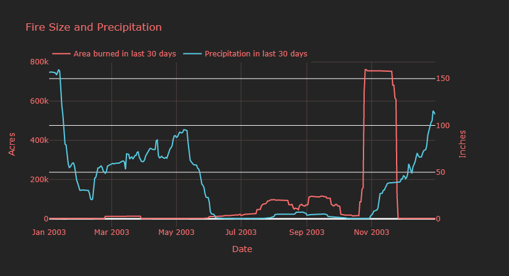

Preview

```python
ChartVisualizer = ChartCreator(yearlyData, caliCounties, daily, fsize_p90, allsize, 2003, "show_firesize_v_precip")
fig = ChartVisualizer.DetermineWhichPlot()
fig
```

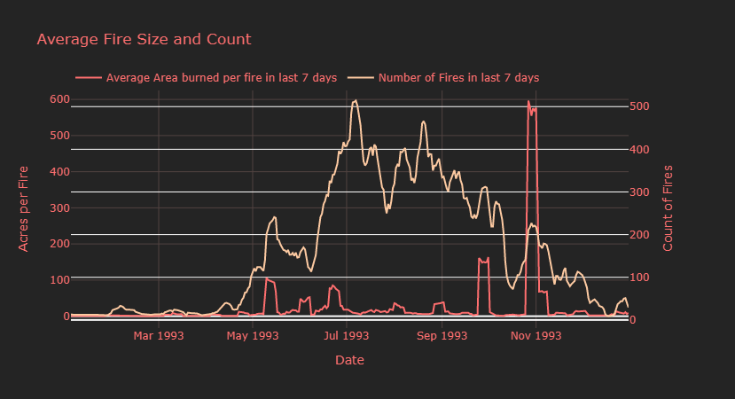

Preview

```python
ChartVisualizer = ChartCreator(yearlyData, caliCounties, daily, fsize_p90, allsize, 1993, "show_avg_firesize_counts_w")
fig = ChartVisualizer.DetermineWhichPlot()
fig
```

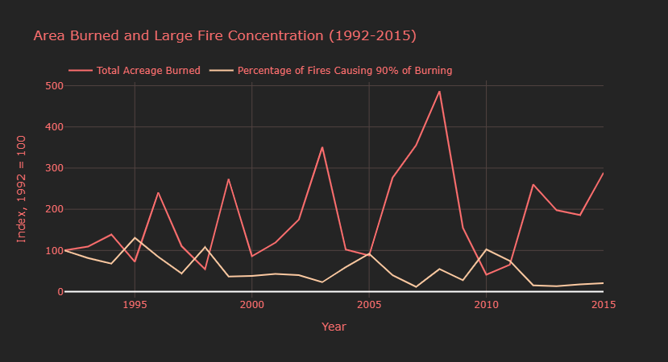

Preview

```python
ChartVisualizer = ChartCreator(yearlyData, caliCounties, daily, fsize_p90, allsize, 2015, "show_indexplot")
fig = ChartVisualizer.DetermineWhichPlot()
fig
```

# Unit Testing

#### Using setUpClass classmethod

- Create the objects necessary for each function to run properly in a classmethod to reduce unnecessary duplication.
- Only objects that remain consistent across all functions are created in the classmethod.
- Objects that change based on desired output are created within the test functions.

```python
import unittest
from numpy import nan
from pandas import Timestamp

FIREPATH = './data/fires_cleaned/final_fires_cleaned.csv'
PRECIP_PATH = './data/precip_agg_series.csv'
startYear = 1992
```

#### Tests for the FirePrecipDataCollection class

```python
# Testing the functions within the FirePrecipDataCollection class.
class FirePrecipDataCollection_Test(unittest.TestCase):

    # Create the objects necessary for each function to run properly in a classmethod to reduce unnecessary duplication.
    # Only objects that remain consistent across all functions are created in the classmethod.
    # Objects that change based on desired output are created within the test functions.
    @classmethod
    def setUpClass(cls):
        cls.DataCollector = FirePrecipDataCollection(1992, FIREPATH, PRECIP_PATH)


    def test_readInData_FIREPATH(self):
        expected_FIPS = ['06063','06017','06003','06005','06089','06093','06009','06023','06037',
                        '06051','06065','06019','06029','06111','06053','06109','06083','06079',
                        '06107','06071','06073','06033','06035','06103','06007','06091','06061',
                        '06049','06105','06027','06057','06015','06115','06045','06021','06043',
                        '06059','06039','06011','06085','06031','06097','06025','06067','06047',
                        '06069','06101','06099','06001','06013','06113','06055','06075','06081',
                        '06041','06087','06095','06077']
        data = self.DataCollector.readInData(FIREPATH)
        self.assertEqual(data['STCT_FIPS'].unique().tolist(), expected_FIPS)


    def test_readInData_PRECIP_PATH(self):
        expected_FIPS = ['06001','06003','06005','06007','06009','06013','06015','06017','06019',
                        '06021','06023','06025','06027','06029','06031','06033','06035','06037',
                        '06039','06041','06043','06045','06047','06049','06051','06053','06055',
                        '06057','06059','06061','06063','06065','06067','06069','06071','06073',
                        '06075','06077','06079','06081','06083','06085','06087','06089','06091',
                        '06093','06095','06097','06099','06103','06105','06107','06109','06111',
                        '06113','06115']
        data = self.DataCollector.readInData(PRECIP_PATH)
        self.assertEqual(data['STCT_FIPS'].unique().tolist(), expected_FIPS)


    def test_getFiresData_fires(self):
        expected_fires = pd.DataFrame({'Unnamed: 0': {0: 0, 1: 1, 2: 2},
                                       'OBJECTID': {0: 1, 1: 1446, 2: 1793},
                                       'FIRE_YEAR': {0: 2005, 1: 2005, 2: 2005},
                                       'STAT_CAUSE_DESCR': {0: 'Miscellaneous', 1: 'Miscellaneous', 2: 'Miscellaneous'},
                                       'FIRE_SIZE': {0: 0.1, 1: 0.1, 2: 0.1},
                                       'FIRE_SIZE_CLASS': {0: 'A', 1: 'A', 2: 'A'},
                                       'LATITUDE': {0: 40.03694444, 1: 40.00472222, 2: 40.09305556},
                                       'LONGITUDE': {0: -121.00583333, 1: -121.26055556, 2: -120.91},
                                       'GEOID': {0: 60630004002, 1: 60630004002, 2: 60630004002},
                                       'STCT_FIPS': {0: '06063', 1: '06063', 2: '06063'},
                                       'DATETIME': {0: '2005-02-02', 1: '2005-08-24', 2: '2005-08-25'},
                                       'MONTH': {0: 'February', 1: 'August', 2: 'August'}})
        fires, _years = self.DataCollector.getFiresData()
        pd.testing.assert_frame_equal(fires.head(3), expected_fires)

    def test_getFiresData_fires_shape(self):
        fires, _years = self.DataCollector.getFiresData()
        self.assertEqual(fires.shape, (189411, 12))

    def test_getFiresData_years(self):
        expected_years_sorted = np.array([1992, 1993, 1994, 1995, 1996, 1997, 1998, 1999, 2000, 2001, 2002, 2003, 2004, 2005, 2006, 2007, 2008, 2009, 2010, 2011, 2012, 2013, 2014, 2015])
        _fires, years = self.DataCollector.getFiresData()
        np.testing.assert_array_equal(np.sort(years), expected_years_sorted)

    def test_getPrecipData(self):
        expected_precip = pd.DataFrame({'STCT_FIPS': {450069: '06115', 450070: '06115', 450071: '06115'},
                                        'date': {450069: Timestamp('2013-12-30 00:00:00'), 450070: Timestamp('2013-12-31 00:00:00'), 450071: Timestamp('2014-01-01 00:00:00')},
                                        'station_sum': {450069: 0.0, 450070: 0.0, 450071: 0.0},
                                        'station_mean': {450069: 0.0, 450070: 0.0, 450071: 0.0},
                                        'past30_ss_sum': {450069: 1.570000000000519, 450070: 1.470000000000519, 450071: 1.470000000000519},
                                        'past30_sm_sum': {450069: 0.3924999999997176, 450070: 0.3674999999997176, 450071: 0.3674999999997176},
                                        'year': {450069: 2013, 450070: 2013, 450071: 2014},
                                        'month': {450069: 12, 450070: 12, 450071: 1},
                                        'day': {450069: 30, 450070: 31, 450071: 1}})
        precip = self.DataCollector.getPrecipData()
        pd.testing.assert_frame_equal(precip.tail(3), expected_precip, check_dtype=True)

    def test_getPrecipData_shape(self):
        precip = self.DataCollector.getPrecipData()
        self.assertEqual(precip.shape, (450072, 9))

    def test_prepPrecipDailyData_columns(self):
        pdaily = self.DataCollector.prepPrecipDailyData()
        self.assertEqual(pdaily.columns.tolist(), ['date', 'station_sum', 'p30'])

    def test_prepPrecipDailyData_shape(self):
        pdaily = self.DataCollector.prepPrecipDailyData()
        self.assertEqual(pdaily.shape, (8037, 3))

    def test_prepFireDailyData_columns(self):
        fdaily = self.DataCollector.prepFireDailyData()
        self.assertEqual(fdaily.columns.tolist(), ['date', 'FIRE_SIZE', 'b30', 'f7', 'f30', 'b7'])

    def test_prepFireDailyData_shape(self):
        fdaily = self.DataCollector.prepFireDailyData()
        self.assertEqual(fdaily.shape, (8323, 6))

    def test_mergeFirePrecipDataDaily(self):
        expected_daily = pd.DataFrame({'date': {8320: Timestamp('2015-12-29 00:00:00'), 8321: Timestamp('2015-12-30 00:00:00'), 8322: Timestamp('2015-12-31 00:00:00')},
                                       'FIRE_SIZE': {8320: 0.12, 8321: 0.1, 8322: 0.22000000000000003},
                                       'b30': {8320: 1361.7600000001164, 8321: 1359.3300000001163, 8322: 1356.6200000001163},
                                       'f7': {8320: 22.0, 8321: 21.0, 8322: 24.0},
                                       'f30': {8320: 147.0, 8321: 137.0, 8322: 130.0},
                                       'b7': {8320: 1292.1900000000583, 8321: 1292.1800000000583, 8322: 1292.3900000000583},
                                       'station_sum': {8320: nan, 8321: nan, 8322: nan},
                                       'p30': {8320: nan, 8321: nan, 8322: nan},
                                       'a7': {8320: 58.73590909091174, 8321: 61.532380952383726, 8322: 53.849583333335765},
                                       'a30': {8320: 9.263673469388547, 8321: 9.922116788322016, 8322: 10.435538461539355}})
        daily = self.DataCollector.mergeFirePrecipDataDaily()
        pd.testing.assert_frame_equal(daily.tail(3), expected_daily, check_dtype=True)

    def test_mergeFirePrecipDataDaily_shape(self):
        daily = self.DataCollector.mergeFirePrecipDataDaily()
        self.assertEqual(daily.shape, (8323, 10))

    def test_getTotalFireSizeAnd90PctTable_columns(self):
        expected_fsize_p90 = pd.DataFrame({'FIRE_YEAR': {0: 1992, 1: 1993, 2: 1994},
                                           'FIRE_SIZE': {0: 294017.5999999876, 1: 321468.8999999812, 2: 407943.3999999603},
                                           'Total Fires': {0: 10808, 1: 8265, 2: 8645},
                                           'nf90': {0: 0.01924500370096225, 1: 0.01572897761645493, 2: 0.013071139386928861},
                                           'nf90_index': {0: 100.0, 1: 81.73018753781004, 2: 67.91965119900343},
                                           'fsize_index': {0: 100.0, 1: 109.33661794395805, 2: 138.747952503516}})
        fsize_p90 = self.DataCollector.getTotalFireSizeAnd90PctTable()
        self.assertEqual(fsize_p90.columns.tolist(), ['FIRE_YEAR', 'FIRE_SIZE', 'Total Fires', 'nf90', 'nf90_index', 'fsize_index'])

    def test_getTotalFireSizeAnd90PctTable_shape(self):
        fsize_p90 = self.DataCollector.getTotalFireSizeAnd90PctTable()
        self.assertEqual(fsize_p90.shape, (24, 6))
```

#### Tests for the CaliforniaYearlyCounty class

```python
# Testing the functions within the CaliforniaYearlyCounty class.
class CaliforniaYearlyCounty_Test(unittest.TestCase):

    # Create the objects necessary for each function to run properly in a classmethod to reduce unnecessary duplication.
    # Only objects that remain consistent across all functions are created in the classmethod.
    # Objects that change based on desired output are created within the test functions.
    @classmethod
    def setUpClass(cls):
        DataCollector = FirePrecipDataCollection(startYear, FIREPATH, PRECIP_PATH)
        fires, years = DataCollector.getFiresData()
        precip = DataCollector.getPrecipData()
        daily = DataCollector.mergeFirePrecipDataDaily()
        cls.CountyDataCollector = CaliforniaYearlyCounty(startYear, fires, years)

    def test_getYearlyDataDict_shape(self):
        yearlyData = self.CountyDataCollector.getYearlyDataDict()
        lengths = [len(yearlyData[year]) for year in yearlyData]
        self.assertEqual(lengths, [6670, 8268, 10142, 7740, 6938, 10808, 8265, 8645, 7366, 9159, 7922, 6853, 8894, 6969, 8176, 7126, 7904, 7410, 5776, 8561, 7225, 8720, 6499, 7375])

    def test_getCaliGeoJson_shape(self):
        cali = self.CountyDataCollector.getCaliGeoJson()
        lengths = [len(feature) for feature in cali['features']]
        self.assertEqual(lengths, [4]*58)

    def test_getCountyNames_shape(self):
        cali = self.CountyDataCollector.getCaliGeoJson()
        caliCounties = self.CountyDataCollector.getCountyNames(cali)
        self.assertEqual(caliCounties.shape, (58, 2))
```

#### Tests for the FireAggregations class

```python
# Testing the functions within the FireAggregations class.
class FireAggregations_Test(unittest.TestCase):

    # Create the objects necessary for each function to run properly in a classmethod to reduce unnecessary duplication.
    # Only objects that remain consistent across all functions are created in the classmethod.
    # Objects that change based on desired output are created within the test functions.
    @classmethod
    def setUpClass(cls):
        DataCollector = FirePrecipDataCollection(startYear, FIREPATH, PRECIP_PATH)
        fires, years = DataCollector.getFiresData()
        precip = DataCollector.getPrecipData()
        daily = DataCollector.mergeFirePrecipDataDaily()
        CountyDataCollector = CaliforniaYearlyCounty(startYear, fires, years)
        yearlyData = CountyDataCollector.getYearlyDataDict()
        cali = CountyDataCollector.getCaliGeoJson()
        caliCounties = CountyDataCollector.getCountyNames(cali)
        cls.FireAggregator = FireAggregations(yearlyData, caliCounties, daily)
        cls.selected_year = 2003 # set to 2003 to passively test the ability to set the start year

    def test_performGroupOperation_count(self):
        expected_df = pd.DataFrame({'fips': {0: '06031', 1: '06041', 2: '06075'},
                                    'fire_count': {0: 1, 1: 2, 2: 3}})
        df = self.FireAggregator.performGroupOperation(2003, 'OBJECTID', 'STCT_FIPS', 'fire_count', 'fips', Type="Count", ascending=True)
        pd.testing.assert_frame_equal(df.head(3), expected_df, check_dtype=True)

    def test_performGroupOperation_sum(self):
        expected_df = pd.DataFrame({'fips': {0: '06041', 1: '06031', 2: '06111'},
                                    'fire_count': {0: 710927, 1: 1069336, 2: 1625188}})
        df = self.FireAggregator.performGroupOperation(2003, 'OBJECTID', 'STCT_FIPS', 'fire_count', 'fips', Type="Sum", ascending=True)
        pd.testing.assert_frame_equal(df.head(3), expected_df, check_dtype=True)

    def test_performGroupOperation_mean(self):
        expected_df = pd.DataFrame({'fips': {0: '06003', 1: '06111', 2: '06091'},
                                    'fire_count': {0: 162902.49295774646, 1: 180576.44444444444, 2: 187794.0}})
        df = self.FireAggregator.performGroupOperation(2003, 'OBJECTID', 'STCT_FIPS', 'fire_count', 'fips', Type="Mean", ascending=True)
        pd.testing.assert_frame_equal(df.head(3), expected_df, check_dtype=True)

    def test_performGroupOperation_shape(self):
        df = self.FireAggregator.performGroupOperation(2003, 'OBJECTID', 'STCT_FIPS', 'fire_count', 'fips', Type="Mean", ascending=True)
        self.assertEqual(df.shape, (58, 2))

    def test_getFireCountsByYear_columns(self):
        fire_counts_by_year = self.FireAggregator.getFireCountsByYear(self.selected_year)
        self.assertEqual(fire_counts_by_year.columns.tolist(), ['fips', 'fire_count', 'county'])

    def test_getFireCountsByYear_shape(self):
        fire_counts_by_year = self.FireAggregator.getFireCountsByYear(self.selected_year)
        self.assertEqual(fire_counts_by_year.shape, (58, 3))

    def test_getFireCatalystsByYear_columns(self):
        fire_catalysts_by_year = self.FireAggregator.getFireCatalystsByYear(self.selected_year)
        self.assertEqual(fire_catalysts_by_year.columns.tolist(), ['catalyst', 'fire_count'])

    def test_getFireCatalystsByYear_shape(self):
        fire_catalysts_by_year = self.FireAggregator.getFireCatalystsByYear(self.selected_year)
        self.assertEqual(fire_catalysts_by_year.shape, (13, 2))

    def test_getMostAcresBurntFipsByYear_columns(self):
        acres_burnt_by_year = self.FireAggregator.getMostAcresBurntFipsByYear(self.selected_year)
        self.assertEqual(acres_burnt_by_year.columns.tolist(), ['fips', 'total_acres_burnt', 'county'])

    def test_getMostAcresBurntFipsByYear_shape(self):
        acres_burnt_by_year = self.FireAggregator.getMostAcresBurntFipsByYear(self.selected_year)
        self.assertEqual(acres_burnt_by_year.shape, (10, 3))

    def test_getAvgFireCatalystsByYear_columns(self):
        catalysts_by_year_avg = self.FireAggregator.getAvgFireCatalystsByYear(self.selected_year)
        self.assertEqual(catalysts_by_year_avg.columns.tolist(), ['catalyst', 'fire_avg_size'])

    def test_getAvgFireCatalystsByYear_shape(self):
        catalysts_by_year_avg = self.FireAggregator.getAvgFireCatalystsByYear(self.selected_year)
        self.assertEqual(catalysts_by_year_avg.shape, (13, 2))

    def test_getFireOverTimeByYear_columns(self):
        fires_over_time_C = self.FireAggregator.getFireOverTimeByYear(self.selected_year)
        self.assertEqual(fires_over_time_C.columns.tolist(), ['index', 'Time', 'fire_size'])

    def test_getFireOverTimeByYear_shape(self):
        fires_over_time_C = self.FireAggregator.getFireOverTimeByYear(self.selected_year)
        self.assertEqual(fires_over_time_C.shape, (7904, 3))

    def test_getAllFireSizes(self):
        allsize = self.FireAggregator.getAllFireSizes()
        allsize = allsize[:10].tolist()
        self.assertEqual(allsize, [0.1, 0.1, 0.1, 0.1, 2.0, 0.1, 0.1, 0.1, 0.5, 0.2])

    def test_getAllFireSizes_shape(self):
        allsize = self.FireAggregator.getAllFireSizes()
        self.assertEqual(allsize.shape, (189411,))
```

#### Tests for the MapCreator class

```python
# Testing the functions within the MapCreator class.
class MapCreator_Test(unittest.TestCase):

    # Create the objects necessary for each function to run properly in a classmethod to reduce unnecessary duplication.
    # Only objects that remain consistent across all functions are created in the classmethod.
    # Objects that change based on desired output are created within the test functions.
    @classmethod
    def setUpClass(cls):
        DataCollector = FirePrecipDataCollection(startYear, FIREPATH, PRECIP_PATH)
        fires, years = DataCollector.getFiresData()
        precip = DataCollector.getPrecipData()
        daily = DataCollector.mergeFirePrecipDataDaily()
        CountyDataCollector = CaliforniaYearlyCounty(startYear, fires, years)
        yearlyData = CountyDataCollector.getYearlyDataDict()
        cls.cali = CountyDataCollector.getCaliGeoJson()
        caliCounties = CountyDataCollector.getCountyNames(cls.cali)
        cls.FireAggregator = FireAggregations(yearlyData, caliCounties, daily)
        cls.selected_year = 1992
        cls.Visualizer = MapCreator(cls.selected_year)

    def test_MakeWildfireMap_fig(self):
        filtered_fires_by_fips = self.FireAggregator.getFireCountsByYear(self.selected_year)
        fig = self.Visualizer.MakeWildfireMap(self.cali, filtered_fires_by_fips)
        self.assertIsNotNone(fig)

    def test_MakeWildfireMap_Mapbox(self):
        filtered_fires_by_fips = self.FireAggregator.getFireCountsByYear(self.selected_year)
        fig = self.Visualizer.MakeWildfireMap(self.cali, filtered_fires_by_fips)
        expected = ("pk.eyJ1IjoiY3NjaHJvZWQiLCJhIjoiY2s3YjJwcWk1MDFyNzNrbnpiaGdlajltbCJ9.8jO290WpRrStFoFl6oXDdA", "mapbox://styles/cschroed/cknl0nnlf219117qmeizntn9q")
        returned = (fig['layout']['mapbox']['accesstoken'], fig['layout']['mapbox']['style'])
        self.assertEqual(returned, expected)
```

#### Tests for the ChartCreator class

```python
# Testing the functions within the ChartCreator class.
class ChartCreator_Test(unittest.TestCase):

    # Create the objects necessary for each function to run properly in a classmethod to reduce unnecessary duplication.
    # Only objects that remain consistent across all functions are created in the classmethod.
    # Objects that change based on desired output are created within the test functions.
    @classmethod
    def setUpClass(cls):
        DataCollector = FirePrecipDataCollection(startYear, FIREPATH, PRECIP_PATH)
        fires, years = DataCollector.getFiresData()
        precip = DataCollector.getPrecipData()
        CountyDataCollector = CaliforniaYearlyCounty(startYear, fires, years)
        cls.yearlyData = CountyDataCollector.getYearlyDataDict()
        cls.caliCounties = CountyDataCollector.getCountyNames(CountyDataCollector.getCaliGeoJson())
        cls.daily = DataCollector.mergeFirePrecipDataDaily()
        cls.fsize_p90 =  DataCollector.getTotalFireSizeAnd90PctTable()
        cls.FireAggregator = FireAggregations(cls.yearlyData, cls.caliCounties, cls.daily)
        cls.allsize = cls.FireAggregator.getAllFireSizes()
        cls.selected_year = 1992

    def test_ChartStyling_BarChart(self):
        ChartVisualizer = ChartCreator(self.yearlyData, self.caliCounties, self.daily, self.fsize_p90, self.allsize, self.selected_year, "show_fire_catalysts_single_year")
        catalysts_by_year = self.FireAggregator.getFireCatalystsByYear(self.selected_year)
        title = "Fires by Catalyst" + ", <b>{0}</b>".format(self.selected_year)
        fig = px.bar(catalysts_by_year, x='catalyst', y='fire_count', title=title)
        self.assertEqual(fig["layout"]["title"]["text"],"Fires by Catalyst, <b>1992</b>")

    def test_ChartStyling_ScatterPlot(self):
        ChartVisualizer = ChartCreator(self.yearlyData, self.caliCounties, self.daily, self.fsize_p90, self.allsize, self.selected_year, "show_fire_over_time_single_year_C")
        fires_over_time_C = self.FireAggregator.getFireOverTimeByYear(self.selected_year)
        fires_over_time_C = fires_over_time_C[fires_over_time_C['fire_size'] < 100]
        fig = px.scatter(fires_over_time_C, x='Time', y='fire_size', color="fire_size", color_continuous_scale="redor", range_color=[0,100], title = "Fire Size Over Time (Class A-C)")
        ChartVisualizer.ChartStyling(fig, t="S")
        self.assertEqual(fig["layout"]["xaxis"]["title"]["text"],"")

    def test_ChartStyling_TwoLinePlot(self):
        ChartVisualizer = ChartCreator(self.yearlyData, self.caliCounties, self.daily, self.fsize_p90, self.allsize, self.selected_year, "show_firesize_v_precip")
        fig = make_subplots(specs=[[{"secondary_y": True}]])
        fd = self.daily[self.daily['date'].dt.year == self.selected_year]
        fig.add_trace(go.Scatter(x=fd['date'], y=fd['b30'], name="Area burned in last 30 days"),secondary_y=False)
        fig.add_trace(go.Scatter(x=fd['date'], y=fd['p30'], name="Precipitation in last 30 days"),secondary_y=True)
        fig.update_layout(title_text="Fire Size and Precipitation", legend = dict(orientation = "h",x=0,y=1.1),)
        fig.update_xaxes(title_text="Date")
        fig.update_yaxes(title_text="Acres", secondary_y=False)
        fig.update_yaxes(title_text="Inches", secondary_y=True)
        ChartVisualizer.ChartStyling(fig, t="L2")
        self.assertEqual(fig["data"][1]["marker"]["color"],"#58cce3")

    def test_BarChart_fig(self):
        ChartVisualizer = ChartCreator(self.yearlyData, self.caliCounties, self.daily, self.fsize_p90, self.allsize, self.selected_year, "show_fire_catalysts_single_year")
        catalysts_by_year = self.FireAggregator.getFireCatalystsByYear(self.selected_year)
        fig = ChartVisualizer.BarChart(catalysts_by_year, 'catalyst', 'fire_count', "Fires by Catalyst", "Number of Fires", "Fire Catalyst")
        self.assertIsNotNone(fig)

    def test_ScatterPlot_fig(self):
        ChartVisualizer = ChartCreator(self.yearlyData, self.caliCounties, self.daily, self.fsize_p90, self.allsize, self.selected_year, "show_fire_over_time_single_year_C")
        fires_over_time_C = self.FireAggregator.getFireOverTimeByYear(self.selected_year)
        fires_over_time_C = fires_over_time_C[fires_over_time_C['fire_size'] < 100]
        fig = ChartVisualizer.ScatterPlot(fires_over_time_C , flag="Y")
        self.assertIsNotNone(fig)

    def test_twoLinePlot_fig(self):
        ChartVisualizer = ChartCreator(self.yearlyData, self.caliCounties, self.daily, self.fsize_p90, self.allsize, self.selected_year, "show_firesize_v_precip")
        catalysts_by_year = self.FireAggregator.getFireCatalystsByYear(self.selected_year)
        fig = ChartVisualizer.twoLinePlot(title = "Fire Size and Precipitation",
                                    y1 = 'b30',
                                    y1_title="Area burned in last 30 days",
                                    y1_units = "Acres",
                                    y2 = 'p30',
                                    y2_title = 'Precipitation in last 30 days',
                                    y2_units = 'Inches')
        self.assertIsNotNone(fig)

    def test_DetermineWhichPlot_fig(self):
        ChartVisualizer = ChartCreator(self.yearlyData, self.caliCounties, self.daily, self.fsize_p90, self.allsize, self.selected_year, "show_fire_over_time_single_year_C")
        fig = ChartVisualizer.DetermineWhichPlot()
        self.assertIsNotNone(fig)
```

```python
if __name__ == '__main__':
    unittest.main(argv=[''], verbosity=1, exit=False)
```

```
...........................................
----------------------------------------------------------------------
Ran 43 tests in 23.419s

OK
```